# Analyzing Stocks Using R

SW

2024-10-06

```r
# Load the required packages
library(quantmod)
library(xts)
library(rvest)
library(tidyverse)
library(stringr)
library(forcats)
library(lubridate)
library(plotly)
library(dplyr)
library(PerformanceAnalytics)
```

## Investment rules

### IBD Methodology

- Invest in stocks with recent quarterly and annual earnings growth of at least 25%.
- Look for companies that have new, game-changing products and services.
- Consider not-yet-profitable companies, often IPOs, that are generating tremendous revenue growth.

### Keep track of the market

- Market is in a confirmed uptrend and move to cash when stock market goes into a correction.

### Sell signals

- Any stocks that falls 7% or 8% from your purchase price should be jettisoned.
- beware of sharp breaks below the 50-day or 10-week moving average

### Technical Analysis

Please refer to the article [Technical analysis in R](https://rpubs.com/Veroni/1023480) for more information about technical analysis.

## Watching List

Firstly, I create my watching list:

### AI related

```r
# Get raw data
# Type "yahooQF()" to get a list of metrics
ai_tickers <- c("ORCL", "CRM", "PLTR", "V", "UNH", "JPM", "MA", "TM", "SIEGY",
                "LLY", "NVO", "JNJ", "NVDA", "AMD", "ARM", "TSM", "TSLA",
                "UBER", "CKI.L")

what_metrics1 <- yahooQF(c("Name",
                          "Currency",
                          "Last Trade (Price Only)",
                          "52-week Range",
                          "50-day Moving Average",
                          "P/E Ratio",
                          "Dividend Yield"))
ai_stocks <- getQuote(ai_tickers, what = what_metrics1)

# Convert to a more readable format
ai_stocks[, "Yield (%)"] <- ai_stocks[, "Dividend Yield"] * 100
ai_stocks[, "Yield (%)"] <- sprintf(ai_stocks[, "Yield (%)"], fmt = '%.2f')
ai_stocks[, "P/E Ratio"] <- sprintf(ai_stocks[, "P/E Ratio"], fmt = '%.2f')
ai_stocks[, "Trade Time"] <- format(ai_stocks[, "Trade Time"], format = "%b %d, %Y")

# Print the table
library(knitr)
kable(ai_stocks[, c(1:7, 9)], caption = "Latest Performance")
```

Latest Performance

|  | Trade Time | Name | Currency | Last | 52-week Range | 50-day MA | P/E Ratio | Yield (%) |
| --- | --- | --- | --- | --- | --- | --- | --- | --- |
| ORCL | Oct 05, 2024 | Oracle Corporation | USD | 170.86 | 99.26 - 173.99 | 147.8082 | 44.04 | 0.96 |
| CRM | Oct 05, 2024 | Salesforce, Inc. | USD | 287.75 | 193.68 - 318.71 | 258.7348 | 50.22 | 0.28 |
| PLTR | Oct 05, 2024 | Palantir Technologies Inc. | USD | 40.01 | 14.48 - 40.29 | 32.4014 | 235.35 | 0.00 |
| V | Oct 05, 2024 | Visa Inc. | USD | 277.93 | 228.03 - 293.07 | 272.6562 | 29.76 | 0.75 |
| UNH | Oct 05, 2024 | UnitedHealth Group Incorporated | USD | 591.20 | 436.38 - 607.94 | 581.7888 | 39.07 | 1.31 |
| JPM | Oct 05, 2024 | JP Morgan Chase & Co. | USD | 211.22 | 135.19 - 225.48 | 211.0464 | 11.78 | 2.16 |
| MA | Oct 05, 2024 | Mastercard Incorporated | USD | 497.70 | 359.77 - 501.8 | 475.6668 | 38.02 | 0.52 |
| TM | Oct 05, 2024 | Toyota Motor Corporation | USD | 180.02 | 159.04 - 255.23 | 180.3012 | 7.17 | 42.57 |
| SIEGY | Oct 05, 2024 | Siemens AG | USD | 100.89 | 63.31 - 103.0 | 92.0618 | 18.31 | 4.66 |
| LLY | Oct 05, 2024 | Eli Lilly and Company | USD | 887.16 | 547.61 - 972.53 | 897.0296 | 108.72 | 0.55 |
| NVO | Oct 05, 2024 | Novo Nordisk A/S | USD | 115.12 | 90.5 - 148.15 | 130.3418 | 38.76 | 8.60 |
| JNJ | Oct 05, 2024 | Johnson & Johnson | USD | 160.29 | 143.13 - 168.85 | 162.5038 | 24.29 | 3.00 |
| NVDA | Oct 05, 2024 | NVIDIA Corporation | USD | 124.92 | 39.23 - 140.76 | 116.1360 | 58.37 | 0.02 |
| AMD | Oct 05, 2024 | Advanced Micro Devices, Inc. | USD | 170.90 | 93.12 - 227.3 | 147.9860 | 203.45 | 0.00 |
| ARM | Oct 05, 2024 | Arm Holdings plc | USD | 140.55 | 46.5 - 188.75 | 131.6880 | 342.80 | 0.00 |
| TSM | Oct 05, 2024 | Taiwan Semiconductor Manufactur | USD | 181.16 | 84.95 - 193.47 | 168.5292 | 31.95 | 8.36 |
| TSLA | Oct 05, 2024 | Tesla, Inc. | USD | 250.08 | 138.8 - 271.0 | 224.1162 | 70.45 | 0.00 |
| UBER | Oct 05, 2024 | Uber Technologies, Inc. | USD | 74.28 | 40.09 - 82.14 | 70.8430 | 80.74 | 0.00 |
| CKI.L | Oct 04, 2024 | NA | GBp | 522.45 | 510.0 - 598.0 | 556.3543 | 15.83 | 0.50 |

### Others

```r
# Get raw data
# Type "yahooQF()" to get a list of metrics
ot_tickers <- c("WMT", "COST", "SNA", "SWK", "6586.T")

what_metrics1 <- yahooQF(c("Name",
                          "Currency",
                          "Last Trade (Price Only)",
                          "52-week Range",
                          "50-day Moving Average",
                          "P/E Ratio",
                          "Dividend Yield"))
ot_stocks <- getQuote(ot_tickers, what = what_metrics1)

# Convert to a more readable format
ot_stocks[, "Yield (%)"] <- ot_stocks[, "Dividend Yield"] * 100
ot_stocks[, "Yield (%)"] <- sprintf(ot_stocks[, "Yield (%)"], fmt = '%.2f')
ot_stocks[, "P/E Ratio"] <- sprintf(ot_stocks[, "P/E Ratio"], fmt = '%.2f')
ot_stocks[, "Trade Time"] <- format(ot_stocks[, "Trade Time"], format = "%b %d, %Y")

# Print the table
library(knitr)
kable(ot_stocks[, c(1:7, 9)], caption = "Latest Performance")
```

Latest Performance

|  | Trade Time | Name | Currency | Last | 52-week Range | 50-day MA | P/E Ratio | Yield (%) |
| --- | --- | --- | --- | --- | --- | --- | --- | --- |
| WMT | Oct 05, 2024 | Walmart Inc. | USD | 80.94 | 49.84667 - 81.6 | 75.3318 | 42.16 | 0.99 |
| COST | Oct 05, 2024 | Costco Wholesale Corporation | USD | 883.11 | 540.23 - 923.83 | 873.9186 | 53.20 | 0.50 |
| SNA | Oct 05, 2024 | Snap-On Incorporated | USD | 286.74 | 249.84 - 298.49 | 279.8596 | 14.90 | 2.49 |
| SWK | Oct 05, 2024 | Stanley Black & Decker, Inc. | USD | 107.38 | 76.57 - 110.88 | 100.9250 | NA | 3.02 |
| 6586.T | Oct 04, 2024 | MAKITA CORP | JPY | 4991.00 | 3518.0 - 5097.0 | 4634.5800 | 27.70 | 1.15 |

```r
index <- c("^GSPC", "^IXIC", "^DJI", "^FTSE", "^N225","^TWII", "^HSI")

us_tickers <- c("AAPL", "AMZN", "NVDA", "GOLD", "GOOG", "GOOGL", "BLK")

hk_tickers <- c("0001.HK", "0005.HK", "0939.HK")
```

Get some knowledge of their performance first:

```r
# Get raw data
# Type "yahooQF()" to get a list of metrics
what_metrics1 <- yahooQF(c("Name",
                          "Currency",
                          "Last Trade (Price Only)",
                          "52-week Range",
                          "50-day Moving Average",
                          "P/E Ratio",
                          "Dividend Yield"))
stocks <- getQuote(us_tickers, what = what_metrics1)

# Convert to a more readable format
stocks[, "Yield (%)"] <- stocks[, "Dividend Yield"] * 100
stocks[, "Yield (%)"] <- sprintf(stocks[, "Yield (%)"], fmt = '%.2f')
stocks[, "P/E Ratio"] <- sprintf(stocks[, "P/E Ratio"], fmt = '%.2f')
stocks[, "Trade Time"] <- format(stocks[, "Trade Time"], format = "%b %d, %Y")

# Print the table
library(knitr)
kable(stocks[, c(1:7, 9)], caption = "Latest Performance")
```

Latest Performance

|  | Trade Time | Name | Currency | Last | 52-week Range | 50-day MA | P/E Ratio | Yield (%) |
| --- | --- | --- | --- | --- | --- | --- | --- | --- |
| AAPL | Oct 04, 2024 | Apple Inc. | USD | 226.80 | 164.08 - 237.23 | 222.6748 | 34.47 | 0.43 |
| AMZN | Oct 04, 2024 | Amazon.com, Inc. | USD | 186.51 | 118.35 - 201.2 | 179.2540 | 44.41 | 0.00 |
| NVDA | Oct 04, 2024 | NVIDIA Corporation | USD | 124.92 | 39.23 - 140.76 | 116.1360 | 58.37 | 0.02 |
| GOLD | Oct 04, 2024 | Barrick Gold Corporation | USD | 20.11 | 13.76 - 21.21 | 19.5222 | 23.38 | 2.02 |
| GOOG | Oct 04, 2024 | Alphabet Inc. | USD | 168.56 | 121.46 - 193.31 | 163.6022 | 24.15 | 0.12 |
| GOOGL | Oct 04, 2024 | Alphabet Inc. | USD | 167.06 | 120.21 - 191.75 | 162.1302 | 23.97 | 0.12 |
| BLK | Oct 04, 2024 | BlackRock, Inc. | USD | 949.19 | 596.18 - 960.74 | 889.0584 | 23.58 | 2.12 |

```r
# Get raw data
# Type "yahooQF()" to get a list of metrics
hkstocks <- getQuote(hk_tickers, what = what_metrics1)

# Convert to a more readable format
hkstocks[, "Yield (%)"] <- hkstocks[, "Dividend Yield"] * 100
hkstocks[, "Yield (%)"] <- sprintf(hkstocks[, "Yield (%)"], fmt = '%.2f')
hkstocks[, "P/E Ratio"] <- sprintf(hkstocks[, "P/E Ratio"], fmt = '%.2f')
hkstocks[, "Trade Time"] <- format(hkstocks[, "Trade Time"], format = "%b %d, %Y")

# Print the table
library(knitr)
kable(hkstocks[, c(1:7, 9)], caption = "Latest Performance")
```

Latest Performance

|  | Trade Time | Name | Currency | Last | 52-week Range | 50-day MA | P/E Ratio | Yield (%) |
| --- | --- | --- | --- | --- | --- | --- | --- | --- |
| 0001.HK | Oct 04, 2024 | CKH HOLDINGS | HKD | 45.35 | 35.35 - 45.7 | 42.045 | 7.73 | 5.49 |
| 0005.HK | Oct 04, 2024 | HSBC HOLDINGS | HKD | 70.00 | 55.5 - 71.0 | 67.164 | 7.78 | 0.88 |
| 0939.HK | Oct 04, 2024 | CCB | HKD | 6.11 | 4.22 - 6.28 | 5.597 | 4.27 | 6.60 |

```r
what_metrics2 <- yahooQF(c("Name",
                          "Last Trade (Price Only)",
                          "52-week Range",
                          "Currency",
                          "Volume"))
```

```r
getSymbols("^HSI", from="1997-07-02")
```

```
## [1] "HSI"
```

```r
head(HSI, n=5)
```

```
##            HSI.Open HSI.High HSI.Low HSI.Close HSI.Volume HSI.Adjusted
## 1997-07-03  15346.0  15363.6 15035.9   15055.7          0      15055.7
## 1997-07-04  15166.9  15179.5 14727.5   14823.0          0      14823.0
## 1997-07-07  14844.8  15003.0 14723.5   14858.6          0      14858.6
## 1997-07-08  14847.0  14876.1 14686.2   14792.2          0      14792.2
## 1997-07-09  14820.3  14931.6 14659.3   14703.7          0      14703.7
```

```r
tail(HSI, n=3)
```

```
##            HSI.Open HSI.High  HSI.Low HSI.Close HSI.Volume HSI.Adjusted
## 2024-10-02 21289.60 22667.74 21289.60  22443.73 7696286600     22443.73
## 2024-10-03 22484.04 22484.04 21442.25  22113.51 4942180900     22113.51
## 2024-10-04 22015.08 22742.36 21824.68  22736.87 4619951200     22736.87
```

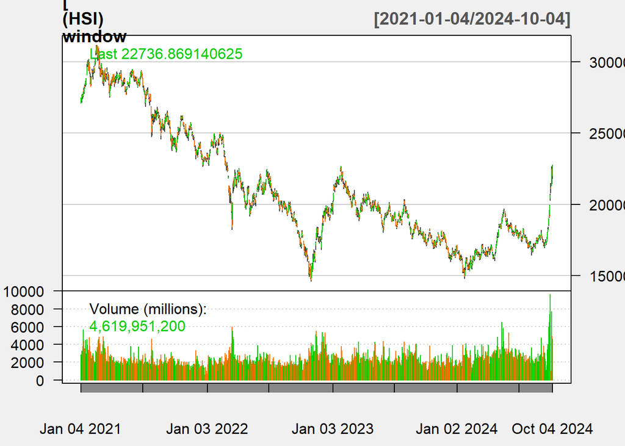

```r
window <- "2021/"
chartSeries((HSI)[window],theme="white")
```

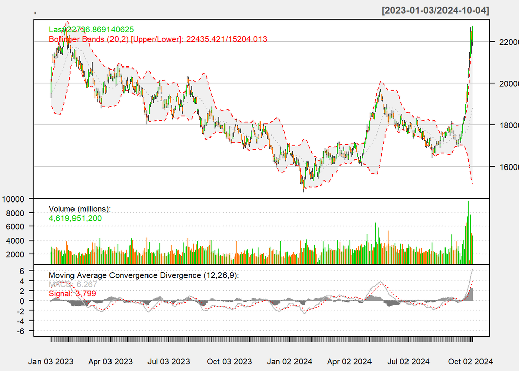

```r
HSI %>% chartSeries(TA='addBBands(); addVo(); addMACD()', subset = '2023/', theme = "white")
```

```r
HSBC.HK <- getSymbols("0005.HK",from="1997-08-17", to=Sys.Date(),
                      auto.assign = FALSE)
```

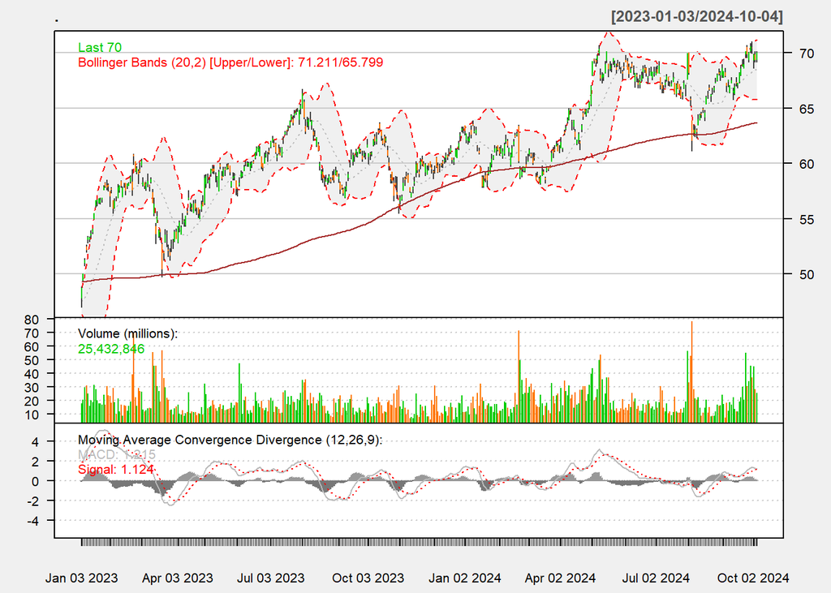

```r
HSBC.HK %>% chartSeries(TA='addBBands(); addSMA(n=250); addVo(); addMACD()', subset = '2023/', theme = "white")
```

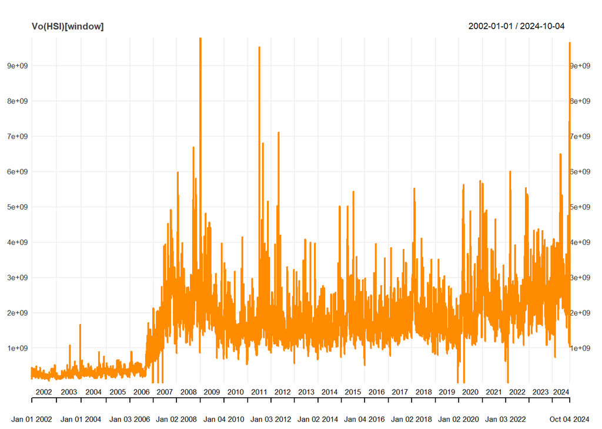

```r
window <- "2002/"
chart_Series(Vo(HSI)[window])
```

```r
getSymbols("AMZN")
```

```
## [1] "AMZN"
```

```r
getSymbols(us_tickers)
```

```
## [1] "AAPL"  "AMZN"  "NVDA"  "GOLD"  "GOOG"  "GOOGL" "BLK"
```

```r
tail(AMZN, n=3)
```

```
##            AMZN.Open AMZN.High AMZN.Low AMZN.Close AMZN.Volume AMZN.Adjusted
## 2024-10-02    184.44    186.60   184.04     184.76    23704100        184.76
## 2024-10-03    183.05    183.44   180.88     181.96    30204300        181.96
## 2024-10-04    185.75    187.60   183.60     186.51    40890300        186.51
```

## Technical Analysis

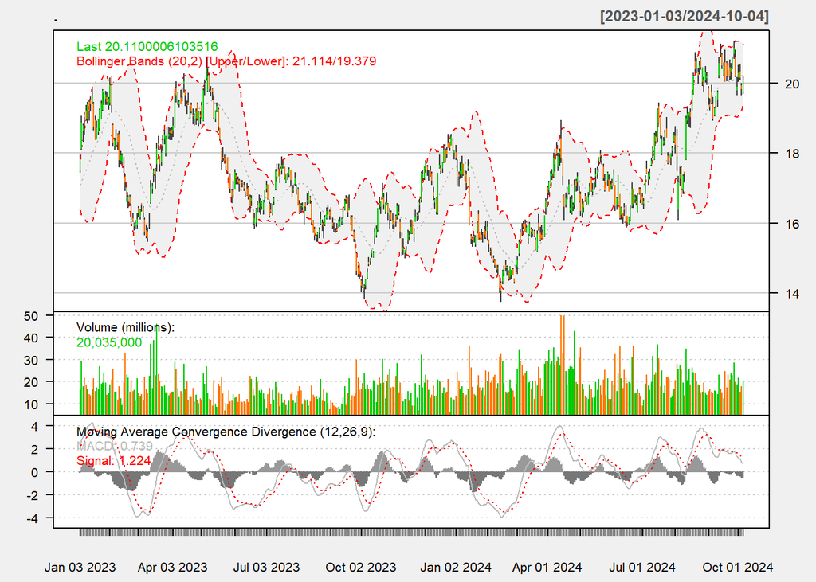

```r
GOLD %>% chartSeries(TA='addBBands(); addVo(); addMACD()', subset = '2023/', theme = "white")
```

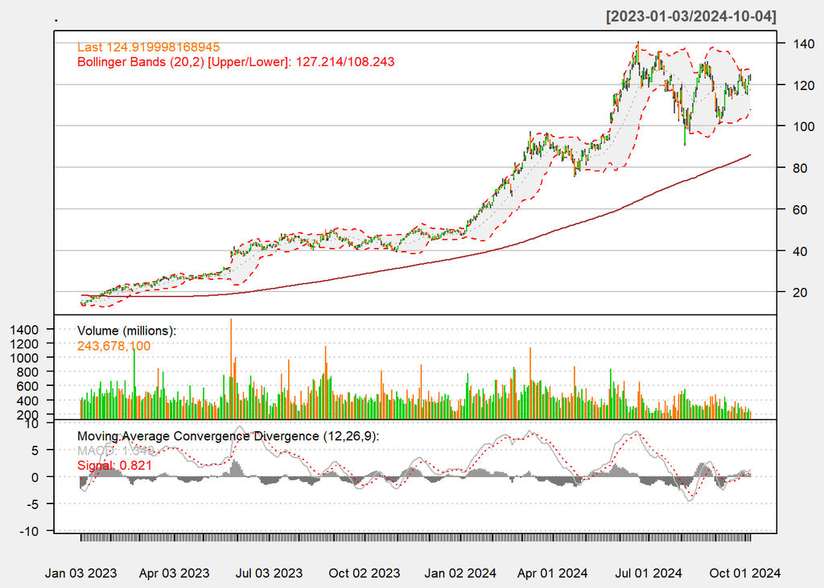

```r
NVDA %>% chartSeries(TA='addBBands(); addSMA(n=250); addVo(); addMACD()', subset = '2023/', theme = "white")
```

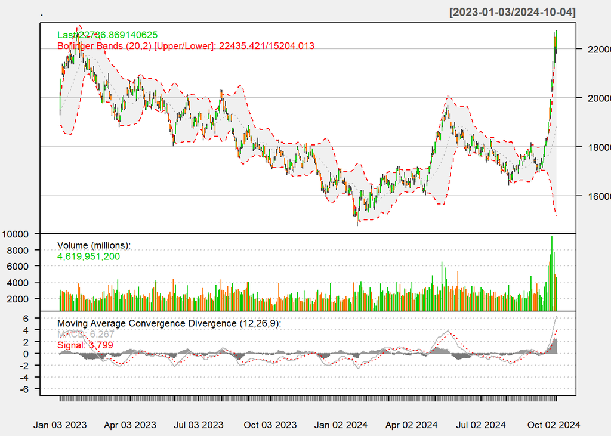

```r
HSI %>% chartSeries(TA='addBBands(); addVo(); addMACD()', subset = '2023/', theme = "white")
```

The Bollinger Band chart plots two standard deviations away from the moving average and is used to measure the stock’s volatility. The Volume chart shows how its stocks are traded on the daily. The Moving Average Convergence Divergence gives technical analysts buy/sell signals. The rule of thumb is: If it falls below the line, it is time to sell. If it rises above the line, it is experiencing an upward momentum.

The charts above are usually used to decide whether to buy/sell a stock. Since I am not a certified financial analyst, I decided to do additional research to convince myself.